# GLM para dados categóricos

Maria Carolina Pacheco

## 1 Introdução

Vou usar o banco de dados de Pinguins que já estávamos utilizando durante a disciplina.

```r
# Abrir os dados
pinguins <- readRDS("../Dados/palmerpenguins_extended.rds")

# Olhar a cara dos dados
View(pinguins)
str(pinguins)
```

```
## 'data.frame':    3430 obs. of  11 variables:
##  $ species          : chr  "Adelie" "Adelie" "Adelie" "Adelie" ...
##  $ island           : chr  "Biscoe" "Biscoe" "Biscoe" "Biscoe" ...
##  $ bill_length_mm   : num  53.4 49.3 55.7 38 60.7 35.7 61 66.1 61.4 54.9 ...
##  $ bill_depth_mm    : num  17.8 18.1 16.6 15.6 17.9 16.8 20.8 20.8 19.9 22.3 ...
##  $ flipper_length_mm: num  219 245 226 221 177 194 211 246 270 230 ...
##  $ body_mass_g      : num  5687 6811 5388 6262 4811 ...
##  $ sex              : chr  "female" "female" "female" "female" ...
##  $ diet             : chr  "fish" "fish" "fish" "fish" ...
##  $ life_stage       : chr  "adult" "adult" "adult" "adult" ...
##  $ health_metrics   : chr  "overweight" "overweight" "overweight" "overweight" ...
##  $ year             : int  2021 2021 2021 2021 2021 2021 2021 2021 2021 2021 ...
```

```r
# Converter as variáveis que vou utilizar em fator
colss <- c("species", "island", "sex", "diet", "life_stage", "health_metrics")
pinguins[, colss] <- lapply(pinguins[, colss], factor)
```

Minha variável resposta vai ser a métrica de saúde dos pinguins:

- Saudável (healthy)
- Sobrepeso (overweight)
- Baixo peso (underweight)

E os preditores vão ser:

- Espécie (species)
- Estágio de vida (life_stage)
- Sexo (sex)

## 2 Análise exploratória

Vou plotar os dados pra relacionar meu y com os preditores;

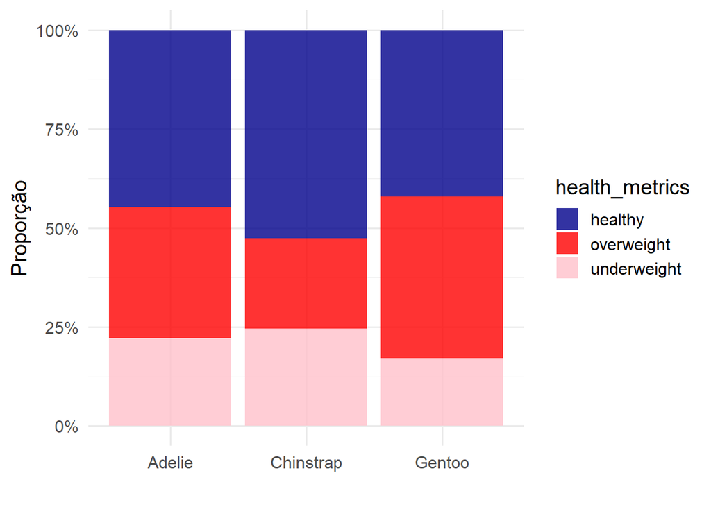

```r
# Métrica de saúde dos pinguins comparando espécies
ggplot(pinguins, aes(x = species, fill = health_metrics)) +
  geom_bar(position = "fill",  alpha = 0.8) +
  scale_y_continuous(labels = scales::percent) +
  scale_fill_manual(values = c("darkblue", "red", "pink")) +
  labs(y = "Proporção", x = "") +
  theme_minimal(base_size = 15)
```

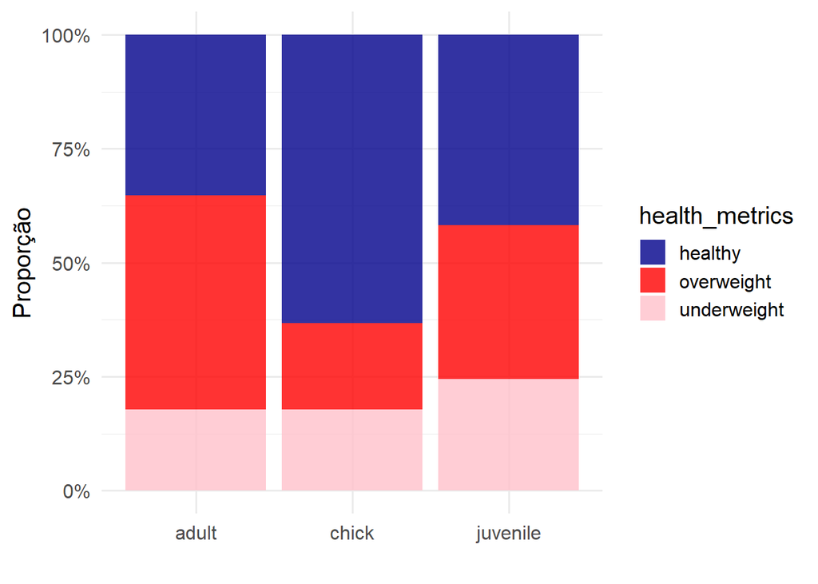

```r
# Métrica de saúde dos pinguins comparando estágios de vida
ggplot(pinguins, aes(x = life_stage, fill = health_metrics)) +
  geom_bar(position = "fill",  alpha = 0.8) +
  scale_y_continuous(labels = scales::percent) +
  scale_fill_manual(values = c("darkblue", "red", "pink")) +
  labs(y = "Proporção", x = "") +
  theme_minimal(base_size = 15)
```

Tem maior proporção de pinguins adultos com sobrepeso. A maioria dos pinguins filhotes é saudável. Parece ter maior prevalência de pinguins abaixo do peso na categoria juvenil.

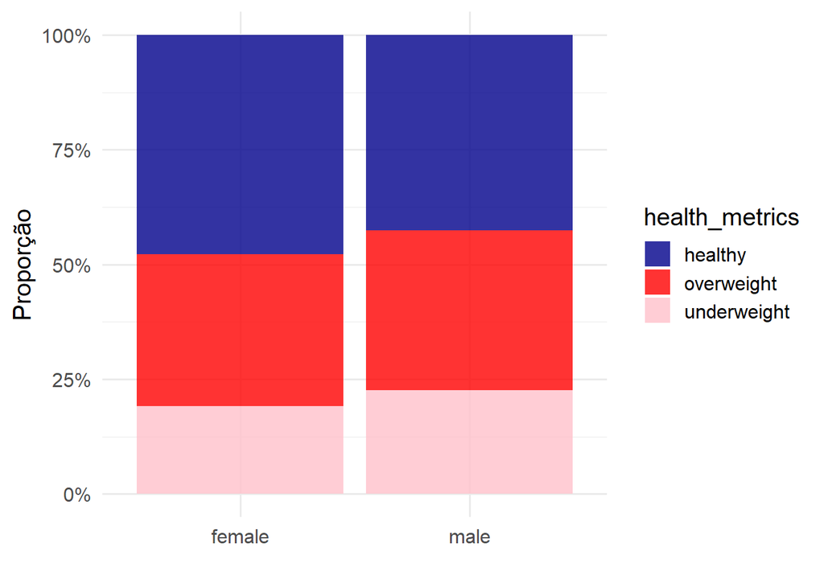

```r
# Métrica de saúde dos pinguins comparando sexo
ggplot(pinguins, aes(x = sex, fill = health_metrics)) +
  geom_bar(position = "fill",  alpha = 0.8) +
  scale_y_continuous(labels = scales::percent) +
  scale_fill_manual(values = c("darkblue", "red","pink")) +
  labs(y = "Proporção", x = "") +
  theme_minimal(base_size = 15)
```

## 3 Análises e resultados

### 3.1 Fazendo o modelo

```r
# Checando os níveis do fator health_metrics para ver qual vai ser o nível de referencia
levels(pinguins$health_metrics) # Vou escolher a referência como healthy (1)
```

```
## [1] "healthy"     "overweight"  "underweight"
```

OBS: 1 = healthy, 2 = overweight, 3 = underweight

#### 3.1.1 Modelo 1

```r
#Modelo 1: Vendo se as métricas de saúde variam entre espécies
mod_pin1 <- vglm(health_metrics ~ species,
family = multinomial(refLevel = 1),  # coloquei 1, entao o modelo vai comparar tudo com healthy
data = pinguins)

# Vamos ver o resultado
summary(mod_pin1)
```

```
##
## Call:
## vglm(formula = health_metrics ~ species, family = multinomial(refLevel = 1),
##     data = pinguins)
##
## Coefficients:
##                    Estimate Std. Error z value Pr(>|z|)
## (Intercept):1      -0.30405    0.05809  -5.234 1.66e-07 ***
## (Intercept):2      -0.69889    0.06568 -10.640  < 2e-16 ***
## speciesChinstrap:1 -0.53313    0.11604  -4.594 4.34e-06 ***
## speciesChinstrap:2 -0.06368    0.11790  -0.540  0.58909
## speciesGentoo:1     0.27697    0.08511   3.254  0.00114 **
## speciesGentoo:2    -0.20131    0.10449  -1.927  0.05403 .
## ---
## Signif. codes:  0 '***' 0.001 '**' 0.01 '*' 0.05 '.' 0.1 ' ' 1
##
## Names of linear predictors: log(mu[,2]/mu[,1]), log(mu[,3]/mu[,1])
##
## Residual deviance: 7151.254 on 6854 degrees of freedom
##
## Log-likelihood: -3575.627 on 6854 degrees of freedom
##
## Number of Fisher scoring iterations: 4
##
## No Hauck-Donner effect found in any of the estimates
##
##
## Reference group is level  1  of the response
```

Agora vamos criar as predições e plotar pra visualizar esses resultados:

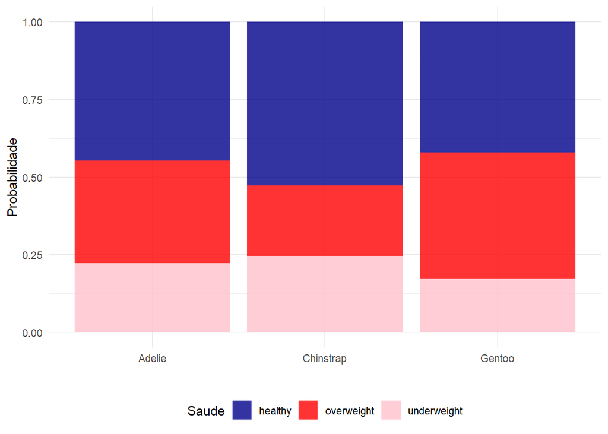

```r
# Predições das probabilidades para cada espécie
dados_pred_pin <- data.frame(species = levels(pinguins$species))
preds_pin <- predict(mod_pin1,
                  newdata = dados_pred_pin,
                  type = "response") %>% data.frame()

preds_pin$species <- dados_pred_pin$species
colnames(preds_pin) <- c("healthy", "overweight", "underweight", "species")

# Aqui estão as nossas predições:
View(preds_pin)

# Colocar no formato long pra poder plotar
preds_pinl <- preds_pin %>%
  tidyr::pivot_longer(cols = c("healthy","overweight", "underweight"),
                      names_to = "health_metrics",
                      values_to = "Probability")

# Plotar as predições
ggplot(preds_pinl, aes(x = species, y = Probability, fill = health_metrics)) +
  geom_bar(stat = "identity", position = "stack",  alpha = 0.8) +
  scale_fill_manual(values = c("healthy" = "darkblue", "overweight" = "red", "underweight" = "pink")) +
  labs(y = "Probabilidade",
       x = "",
       fill = "Saude") +
  theme_minimal() +
  theme(legend.position = "bottom")
```

#### 3.1.2 Modelo 2

```r
# Modelo 2: apenas saúde e estágio de vida
mod_pin2 <- vglm(health_metrics ~ life_stage,
                 family = multinomial(refLevel = 1),  # coloquei 1, entao o modelo vai comparar tudo com healthy
                 data = pinguins)

# vamos ver os resultados
summary(mod_pin2)
```

```
##
## Call:
## vglm(formula = health_metrics ~ life_stage, family = multinomial(refLevel = 1),
##     data = pinguins)
##
## Coefficients:
##                      Estimate Std. Error z value Pr(>|z|)
## (Intercept):1         0.29044    0.06949   4.180 2.92e-05 ***
## (Intercept):2        -0.68216    0.09070  -7.521 5.44e-14 ***
## life_stagechick:1    -1.49564    0.11314 -13.219  < 2e-16 ***
## life_stagechick:2    -0.58635    0.12885  -4.551 5.34e-06 ***
## life_stagejuvenile:1 -0.50431    0.09113  -5.534 3.13e-08 ***
## life_stagejuvenile:2  0.14670    0.11150   1.316    0.188
## ---
## Signif. codes:  0 '***' 0.001 '**' 0.01 '*' 0.05 '.' 0.1 ' ' 1
##
## Names of linear predictors: log(mu[,2]/mu[,1]), log(mu[,3]/mu[,1])
##
## Residual deviance: 7002.468 on 6854 degrees of freedom
##
## Log-likelihood: -3501.234 on 6854 degrees of freedom
##
## Number of Fisher scoring iterations: 4
##
## No Hauck-Donner effect found in any of the estimates
##
##
## Reference group is level  1  of the response
```

- A probabilidade de um pinguim adulto ter sobrepeso é maior que a de ser saudavel. e a probabilidade de ter subpeso é menor
- Para filhotes, as probabilidades de ter sobre e subpeso sao menores que a de ser saudável
- Para juvenis, a probabilidade de sobrepeso é menor que a de ser saudável